# Using gama - a Genetic Approach to Maximize clustering criterion

## Segmentation of an unknown number of partitions

```
## Looking for the best k value by 'broad' method...
## There was found 6 suggestions for k = [ 2, 3, 4, 7, 9, 10 ].
## Best k suggestion by majority voting = 3.
##
##
## Details for the object of class 'gama':
##
## Original data (first rows):
##         user     system    iowait softirq
## 1 0.16239850 0.02498438 0.4996877       0
## 2 0.07497189 0.01249531 0.5622891       0
## 3 0.16237822 0.03747190 0.4746440       0
## 4 0.11241569 0.04996253 0.6120410       0
## 5 0.07495315 0.03747658 0.7495315       0
## 6 0.14985015 0.04995005 0.5619381       0
##
## Cluster partitions:
##   [1] 3 3 3 3 3 3 3 3 3 3 3 3 3 3 3 3 3 3 3 3 3 2 3 3 2 3 2 2 3 3 2 3 3 3 3
##  [36] 1 1 1 1 1 1 1 1 1 1 1 1 1 1 2 2 2 2 2 2 2 2 1 2 2 1 1 2 2 2 2 2 2 2 2
##  [71] 2 2 2 2 2 2 2 2 2 2 2 2 2 2 2 2 2 2 2 2 2 2 2 2 2 2 2 2 2 2 2 2 2 2 2
## [106] 2 2 2 2 2 2 2 2 2 2 2 2 2 2 2 2 2 2 2 2 2 2 2 2 2 2 2 2 2 2 2 2 2 2 2
## [141] 2 2 2 2 2 2 2 2 2 2 2 2 2 2 2 2 2 2 2 2 2 2 2 2 2 2 2 2 2 2 2 2 2 2 2
## [176] 2 2 2 2 2 2 2 2 2 2 2 2 2 2 2 2 2 2 2 2 2 2 2 2 2 2 2 2 2 2 2 2 2 2 2
## [211] 2 2 2 2 2 2 2 2 2 2 2 2 2 2 2 2 2 2 2 2 2 2 2 2 2 2 2 2 2 2 2 2 2 2 2
## [246] 2 2 2 2 2 2 2 2 2 2 2 2 2 2 2 2 2 2 2 2 2 2 2 2 2 2 2 2 2 2 2 2 2 2 2
## [281] 1 2 2 2 2 2 2 2 2 2 2 2 2 2 2 2 2 2 2 2 2 1 1 1 1 1 1 1
##
## Cluster Centers:
##       user   system    iowait   softirq
## 3 11.61683 6.504285 0.5638404 0.1192261
## 2 23.04150 6.109322 0.4010132 0.1845900
## 1 66.35791 3.057684 0.6460705 0.1349795
##
## Average Silhouette Width index (ASW):
## [1] 0.8137554
##
## Calinski Harabasz index (CH):
## [1] 414.4831
##
## C-Index (CI):
## [1] 0.0348298
##
## Dunn index (DI):
## [1] 0.02320579
##
## Call:
## gama(dataset = cpu.als, generations = 150, seed.p = 42, penalty.function = my.penalty)
##
## Runtime:
## Time difference of 6.47 secs
```

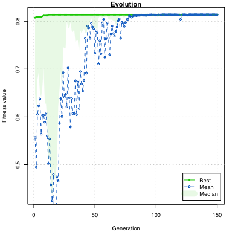

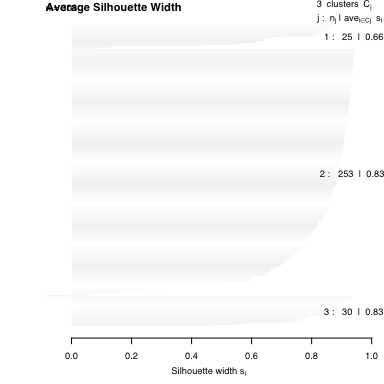

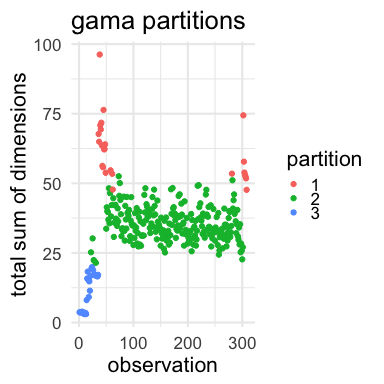

One can observe the parameter view = ‘total.sum’. This kind of partitions visualization plots the sum of all dimensions each observation belongs to. It is specially util in datasets like the cpu.als when the sum of dimensions it is important to the visualization purposes.

## Segmentation of complex datasets

In the next examples, we will be using the aggregation, compound, and path.based datasets. One can observe that the clusters have groups of different density points, varied shapes, and necks between partitions. The datasets contain features that are known to create difficulties for the selected algorithm such as narrow bridges between clusters and uneven-sized clusters. For demonstration purposes, we call gama with a small number of generations. We strongly recommend larger values to complex datasets.

First, a call to the algorithm over the compound dataset with the already *a priori* known number k = 6. The method of evaluation was changed from default (silhouette) to Calinski-Harabasz index to exemplify the adaptable fitness criterion feature.

```
##
## Details for the object of class 'gama':
##
## Original data (first rows):
##      x1    x2
## 1 26.75 22.15
## 2 29.80 22.15
## 3 31.55 21.10
## 4 27.70 20.85
## 5 29.90 19.95
## 6 26.80 19.05
##
## Cluster partitions:
##   [1] 1 5 5 5 5 5 5 5 5 5 5 5 5 4 5 5 5 5 4 4 4 5 2 2 2 2 2 2 2 2 2 2 2 2 2
##  [36] 2 2 2 2 2 2 2 2 2 2 5 5 5 5 2 5 5 5 5 5 5 5 5 5 5 5 5 5 5 5 5 5 5 5 5
##  [71] 5 2 5 2 2 2 2 2 2 2 2 2 2 2 2 2 2 2 2 2 2 2 2 2 2 2 2 2 5 5 5 5 5 5 5
## [106] 5 5 5 5 5 5 5 5 5 5 5 5 5 5 5 5 5 5 5 5 5 5 5 5 5 5 5 5 5 5 5 5 5 5 5
## [141] 5 5 3 3 3 3 3 3 3 3 3 3 3 3 3 3 3 3 3 3 3 3 3 3 3 3 3 3 3 3 3 3 3 3 3
## [176] 3 3 3 3 3 3 1 1 1 1 1 1 1 1 1 1 1 1 1 1 1 1 1 1 1 1 1 1 1 1 1 1 1 1 1
## [211] 1 1 1 1 1 1 1 1 1 1 1 1 1 1 1 6 6 6 6 6 6 6 6 6 6 6 6 6 6 6 6 6 6 6 6
## [246] 6 6 6 6 6 6 6 6 6 6 6 6 6 6 6 6 6 6 6 6 6 6 6 6 6 6 6 6 6 6 6 6 6 6 6
## [281] 6 6 6 6 6 6 6 6 6 6 6 6 6 6 6 6 6 6 6 6 6 6 6 6 6 6 6 6 6 6 4 4 4 4 4
## [316] 6 6 6 6 6 4 4 4 4 4 4 4 4 4 4 4 4 4 4 4 4 4 4 4 4 4 4 4 4 4 4 4 4 4 4
## [351] 4 4 4 4 4 4 4 4 4 4 4 4 4 4 4 4 4 4 4 4 4 4 4 4 4 4 4 4 4 4 4 4 4 4 4
## [386] 4 4 4 4 4 4 6 6 6 6 6 6 6 6
##
## Cluster Centers:
##         x1       x2
## 6 10.27127 12.05669
## 3 10.17120 17.09351
## 4 22.79056 10.66915
## 1 20.22489 20.35384
## 5 32.14655 15.68631
## 2 37.34206 14.41635
##
## Average Silhouette Width index (ASW):
## [1] 0.5978951
##
## Calinski Harabasz index (CH):
## [1] 849.4788
##
## C-Index (CI):
## [1] 0.03711695
##
## Dunn index (DI):
## [1] 0.02963503
##
## Call:
## gama(dataset = compound, k = 6, seed.p = 42, fitness.criterion = "CH",
##     plot.internals = FALSE)
##
## Runtime:
## Time difference of 18.93 secs
```

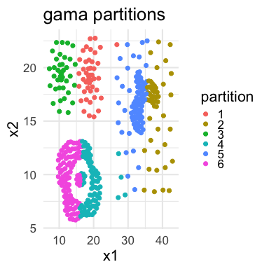

The algorithm has not been able to detect complex forms like the clusters that exist within other clusters.

Second, a call to detect partitions in aggregation dataset (k = 7) and *Dunn* index as fitness criterion.

```
##
## Details for the object of class 'gama':
##
## Original data (first rows):
##      x1    x2
## 1 15.55 28.65
## 2 14.90 27.55
## 3 14.45 28.35
## 4 14.15 28.80
## 5 13.75 28.05
## 6 13.35 28.45
##
## Cluster partitions:
##   [1] 3 3 3 3 3 3 3 3 3 3 3 3 3 3 3 3 3 3 3 3 3 3 3 3 3 3 3 3 3 3 3 3 3 3 3
##  [36] 3 3 3 3 3 3 3 3 3 3 3 3 3 3 3 3 3 3 3 3 3 3 3 3 3 3 3 3 3 3 3 3 3 3 3
##  [71] 3 3 3 3 3 3 3 3 3 3 3 3 3 3 3 3 3 3 3 3 3 3 3 3 3 3 3 3 3 3 3 3 3 3 3
## [106] 3 3 3 3 3 3 3 3 3 3 3 3 3 3 3 3 3 3 3 3 3 3 3 3 3 3 3 3 3 3 3 3 3 3 3
## [141] 3 3 3 3 3 3 3 3 3 3 3 3 3 3 3 3 3 3 3 3 3 3 3 3 3 6 6 6 6 3 2 2 2 2 2
## [176] 2 2 2 2 2 2 2 2 2 2 2 2 2 2 2 2 2 2 2 2 2 2 2 2 2 2 2 2 2 2 2 2 2 2 2
## [211] 2 2 6 6 6 6 6 6 6 6 6 6 6 6 6 6 6 6 6 2 2 2 2 2 2 2 6 6 6 2 2 2 2 2 2
## [246] 6 6 6 6 6 6 6 6 6 6 6 6 6 6 6 6 6 6 6 6 6 6 2 2 2 2 2 2 2 2 2 6 6 2 2
## [281] 2 2 2 2 2 2 6 2 2 2 2 6 6 6 6 2 2 6 6 6 6 6 6 6 6 6 6 6 6 6 6 6 6 6 6
## [316] 6 6 6 6 6 6 6 6 6 6 6 6 6 6 6 6 6 6 6 6 6 6 6 6 6 6 6 6 6 6 6 6 6 6 6
## [351] 6 6 6 6 6 7 7 7 7 7 7 6 7 7 6 6 7 7 6 6 6 6 6 6 6 6 6 6 6 6 6 6 6 6 6
## [386] 6 6 6 6 6 6 6 6 6 6 7 7 7 7 7 7 7 7 4 7 7 7 7 7 7 7 7 7 6 6 6 6 6 6 6
## [421] 6 6 6 6 6 6 6 7 7 6 7 7 7 7 7 7 7 7 7 7 7 7 7 7 7 7 7 7 7 7 7 7 7 7 7
## [456] 7 7 7 7 7 7 7 7 7 7 7 7 7 7 4 7 7 7 7 7 4 4 4 4 4 4 4 4 4 4 4 4 4 4 4
## [491] 4 4 4 4 4 4 4 4 4 4 4 4 4 4 4 4 4 4 4 4 4 4 4 4 4 4 4 4 4 4 4 4 4 4 4
## [526] 4 4 4 4 4 4 4 4 4 4 4 4 4 4 4 4 4 4 4 4 4 4 4 4 4 4 4 4 4 4 4 4 4 4 4
## [561] 4 4 4 4 4 4 4 4 4 4 4 4 4 4 4 4 4 4 4 4 4 4 4 4 4 4 1 1 1 1 1 1 1 1 1
## [596] 1 1 1 1 1 1 1 1 1 1 1 4 4 4 1 1 1 1 1 1 1 1 1 1 1 1 1 1 1 1 1 1 1 1 1
## [631] 1 1 1 1 1 1 1 1 1 1 1 1 1 1 1 1 1 1 1 1 1 1 1 1 1 1 1 1 1 1 1 1 1 1 1
## [666] 1 1 1 1 1 1 1 1 1 1 1 1 1 1 1 1 1 1 1 1 1 1 1 1 1 1 1 1 1 1 1 1 1 1 1
## [701] 1 1 1 1 1 1 1 1 1 5 5 5 5 3 3 5 5 5 5 5 5 5 5 5 5 5 3 3 5 5 3 5 1 1 5
## [736] 5 1 1 1 1 1 1 1 5 5 5 5 5 1 1 1 1 1 1 2 2 2 2 2 2 2 2 2 2 2 2 2 2 2 2
## [771] 2 2 2 2 2 2 2 2 2 2 2 2 2 2 2 2 2 2
##
## Cluster Centers:
##          x1       x2
## 2  6.490798 10.65759
```

[output cut: 10 more lines]

```
## Calinski Harabasz index (CH):
## [1] 1094.469
##
## C-Index (CI):
## [1] 0.04818904
##
## Dunn index (DI):
## [1] 0.032834
##
## Call:
## gama(dataset = aggregation, k = 7, seed.p = 42, fitness.criterion = "DI",
##     plot.internals = FALSE)
##
## Runtime:
## Time difference of 49.39 secs
```

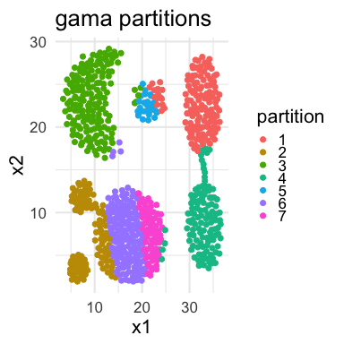

Moreover, the path.based dataset, by calling a specific method to infer the best value for k, before calling the clustering algorithm.

```
## Looking for the best k value by 'minimal' method...
```

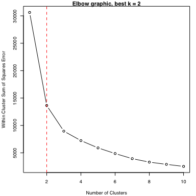

```
## Best k suggestion by using second derivative aproximation over
## 'Within-Cluster Sum of Squares Error' (WCSSE) graphic = 2. See 'elbow' graphic for details.
##
## Details for the object of class 'gama':
##
## Original data (first rows):
##      x1   x2
## 1 11.25 5.05
## 2 10.95 4.70
## 3  9.85 5.80
## 4  9.80 5.75
## 5  9.15 6.80
## 6  8.65 6.60
##
## Cluster partitions:
##   [1] 1 1 1 1 1 1 1 1 1 1 1 1 1 1 1 1 1 1 1 1 1 1 1 1 1 1 1 1 1 1 1 1 1 1 1
##  [36] 1 1 1 1 1 1 1 1 1 1 1 1 1 1 1 1 1 2 2 2 2 2 2 2 2 2 2 2 2 2 2 2 2 2 2
##  [71] 2 2 2 2 2 2 2 2 2 2 2 2 2 2 2 2 2 2 2 2 2 2 2 2 2 2 2 2 2 2 2 2 2 2 2
## [106] 2 2 2 2 2 2 2 2 2 2 2 2 2 2 2 2 2 2 2 2 2 2 2 2 2 2 2 2 2 2 2 2 2 2 2
## [141] 2 2 2 2 2 2 2 2 2 2 2 2 2 2 2 2 2 2 2 2 2 2 2 2 2 2 2 2 2 2 2 2 2 2 2
## [176] 2 2 2 2 2 2 2 2 2 2 2 2 2 2 2 2 2 2 2 2 2 2 2 2 2 2 2 1 1 1 1 1 1 1 1
## [211] 1 1 1 1 1 1 1 1 1 1 1 1 1 1 1 1 1 1 1 1 1 1 1 1 1 1 1 1 1 1 1 1 1 1 1
## [246] 1 1 1 1 1 1 1 1 1 1 1 1 1 1 1 1 1 1 1 1 1 1 1 1 1 1 1 1 1 1 1 1 1 1 1
## [281] 1 1 1 1 1 1 1 1 1 1 1 1 1 1 1 1 1 1 1 1
##
## Cluster Centers:
##         x1       x2
## 1 13.67276 14.23638
## 2 22.62516 13.37190
##
## Average Silhouette Width index (ASW):
## [1] 0.6974735
##
## Calinski Harabasz index (CH):
## [1] 371.0553
##
## C-Index (CI):
## [1] 0.1020544
##
## Dunn index (DI):
## [1] 0.03698117
##
## Call:
## gama(dataset = path.based, k = best.k, seed.p = 42, plot.internals = FALSE)
##
## Runtime:
## Time difference of 3.95 secs
```

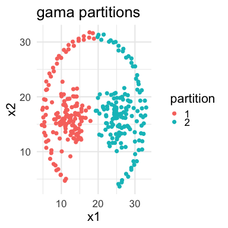

```r
sessionInfo()
## R version 3.5.2 (2018-12-20)
## Platform: x86_64-apple-darwin15.6.0 (64-bit)
## Running under: macOS Mojave 10.14.3
##
## Matrix products: default
## BLAS: /Library/Frameworks/R.framework/Versions/3.5/Resources/lib/libRblas.0.dylib
## LAPACK: /Library/Frameworks/R.framework/Versions/3.5/Resources/lib/libRlapack.dylib
##
## locale:
## [1] C/en_US.UTF-8/en_US.UTF-8/C/en_US.UTF-8/en_US.UTF-8
##
## attached base packages:
## [1] stats     graphics  grDevices utils     datasets  methods   base
##
## other attached packages:
## [1] gama_1.0.3 knitr_1.21
##
## loaded via a namespace (and not attached):
##  [1] Rcpp_1.0.0           GA_3.2               cluster_2.0.7-1
##  [4] magrittr_1.5         NbClust_3.0          munsell_0.5.0
##  [7] colorspace_1.4-0     rlang_0.3.1          foreach_1.4.4
## [10] plyr_1.8.4           stringr_1.3.1        tools_3.5.2
## [13] parallel_3.5.2       Rfast_1.9.2          grid_3.5.2
## [16] gtable_0.2.0         xfun_0.4             cli_1.0.1
## [19] htmltools_0.3.6      iterators_1.0.10     lazyeval_0.2.1
## [22] yaml_2.2.0           digest_0.6.18        assertthat_0.2.0
## [25] clusterCrit_1.2.8    tibble_2.0.1         crayon_1.3.4
## [28] ggplot2_3.1.0        ArgumentCheck_0.10.2 codetools_0.2-15
## [31] evaluate_0.12        rmarkdown_1.11       labeling_0.3
## [34] stringi_1.2.4        pillar_1.3.1         compiler_3.5.2
## [37] scales_1.0.0         RcppZiggurat_0.1.5   pkgconfig_2.0.2
```

# References

Chang, Hong, and Dit-Yan Yeung. 2008. “Robust Path-Based Spectral Clustering.” *Pattern Recognition* 41 (1). Elsevier: 191–203.

Charrad, Malika, Nadia Ghazzali, Véronique Boiteau, and Azam Niknafs. 2014. “NbClust: An R Package for Determining the Relevant Number of Clusters in a Data Set.” *Journal of Statistical Software* 61 (6): 1–36. http://www.jstatsoft.org/v61/i06/.

Desgraupes, Bernard. 2013. “Clustering Indices.” *University of Paris Ouest-Lab Modal’X* 1: 34.

Falkenauer, Emanuel. 1998. *Genetic Algorithms and Grouping Problems*. Wiley New York.

Fränti, Pasi, and Sami Sieranoja. 2018. “K-Means Properties on Six Clustering Benchmark Datasets.” http://cs.uef.fi/sipu/datasets/.

Fu, Limin, and Enzo Medico. 2007. “FLAME, a Novel Fuzzy Clustering Method for the Analysis of Dna Microarray Data.” *BMC Bioinformatics* 8 (1). BioMed Central: 3.

Gionis, Aristides, Heikki Mannila, and Panayiotis Tsaparas. 2007. “Clustering Aggregation.” *ACM Transactions on Knowledge Discovery from Data (TKDD)* 1 (1). ACM: 4.

Goldberg, David, David Nichols, Brian M Oki, and Douglas Terry. 1992. “Using collaborative filtering to weave an information tapestry.” *Communications of the ACM* 35 (12). ACM: 61–70.

Hruschka, Eduardo Raul, Ricardo J G B Campello, Alex A Freitas, and Others. 2009. “A survey of evolutionary algorithms for clustering.” *IEEE Transactions on Systems, Man, and Cybernetics, Part C (Applications and Reviews)* 39 (2). IEEE: 133–55.

Hu, Yifan, Yehuda Koren, and Chris Volinsky. 2008. “Collaborative filtering for implicit feedback datasets.” In *Data Mining, 2008. Icdm’08. Eighth Ieee International Conference on*, 263–72. Ieee.

Huang, Shengsheng, Jie Huang, Jinquan Dai, Tao Xie, and Bo Huang. 2010. “The HiBench benchmark suite: Characterization of the MapReduce-based data analysis.” In *2010 Ieee 26th International Conference on Data Engineering Workshops (Icdew 2010)*, 41–51. IEEE. doi:10.1109/ICDEW.2010.5452747.

Jain, Anil K, and Richard C Dubes. 1988. “Algorithms for Clustering Data.” Prentice-Hall, Inc.

Jain, Anil K. 2010. “Data clustering: 50 years beyond K-means.” *Pattern Recognition Letters* 31 (8). Elsevier B.V.: 651–66. doi:10.1016/j.patrec.2009.09.011.

Jolliffe, I T. 2002. “Principal Component Analysis, Second Edition.” *Encyclopedia of Statistics in Behavioral Science* 30 (3): 487. doi:10.2307/1270093.

Maechler, Martin, Peter Rousseeuw, Anja Struyf, Mia Hubert, and Kurt Hornik. 2018. *Cluster: Cluster Analysis Basics and Extensions*.

Papadakis, Manos, Michail Tsagris, Marios Dimitriadis, Stefanos Fafalios, Ioannis Tsamardinos, Matteo Fasiolo, Giorgos Borboudakis, John Burkardt, Changliang Zou, and Kleanthi Lakiotaki. 2018. *Rfast: A Collection of Efficient and Extremely Fast R Functions*.

Scrucca, Luca. 2013. “GA: A Package for Genetic Algorithms in R.” *Journal of Statistical Software, Articles* 53 (4): 1–37. doi:10.18637/jss.v053.i04.

Xie, Yihui. 2014. “Knitr: A Comprehensive Tool for Reproducible Research in R.” In *Implementing Reproducible Computational Research*, edited by Victoria Stodden, Friedrich Leisch, and Roger D. Peng. Chapman; Hall/CRC. http://www.crcpress.com/product/isbn/9781466561595.

Zahn, Charles T. 1970. “Graph Theoretical Methods for Detecting and Describing Gestalt Clusters.” *IEEE Trans. Comput.* 20 (SLAC-PUB-0672-REV): 68.